# Severe Weather Events due to Health and Economy of the USA

tyanas

Monday, May 11 2015 г.

# Introduction

Storms and other severe weather events can cause both public health and economic problems for communities and municipalities. Many severe events can result in fatalities, injuries, and property damage, and preventing such outcomes to the extent possible is a key concern.

This project involves exploring the U.S. National Oceanic and Atmospheric Administration’s (NOAA) storm database. This database tracks characteristics of major storms and weather events in the United States, including when and where they occur, as well as estimates of any fatalities, injuries, and property damage.

# Overview

We are going to answer following question for the USA: 1. Which types of events (as indicated in the EVTYPE variable) are *most harmful* with respect to population health? 2. Which types of events have *the greatest economic consequences*?

# Data Processing

1. initialize libraries

```r
cache = TRUE
library(dplyr)
```

```r
library(reshape2)
library(ggplot2)

#install.packages("stringr", dependencies=TRUE)
require(stringr)
#example(str_trim)
```

2. prepare the data

```r
filename <- "repdata-data-StormData.csv.bz2"
src_url <- "http://d396qusza40orc.cloudfront.net/repdata%2Fdata%2FStormData.csv.bz2"
if(!file.exists(filename))
    download.file(src_url, destfile = filename)

theDataTest <- read.csv(bzfile(filename), nrows = 1)
```

Let’s inspect data column names (with `colnames(theDataTest)`) in order to find where the data we are interested in is located.

“FATALITIES” and “INJURIES” column are relevant to the health. “PROPDMG” and “CROPDMG” are relevant to the economy. Also we will need “PROPDMGEXP” and “CROPDMGEXP” to interpret data in “PROPDMG” and “CROPDMG” columns.

Let’s get corresponding subsets for the health and ecomony questions. First get all the data.

```r
theData <- read.csv(bzfile(filename))
healthData <- theData[,c('EVTYPE', 'FATALITIES', 'INJURIES')]
economyData <- theData[,c('EVTYPE', 'PROPDMG', 'PROPDMGEXP', 'CROPDMG', 'CROPDMGEXP')]
```

Now the subsets:

```r
healthData <- tbl_df(healthData) %>%
    mutate(
        EVTYPE = as.factor(toupper(str_trim(EVTYPE)))
    )

ecoData <- tbl_df(economyData) %>%
    mutate(
        EVTYPE = as.factor(toupper(str_trim(economyData$EVTYPE))),
        PROPDMGEXP = toupper(economyData$PROPDMGEXP),
        CROPDMGEXP = toupper(economyData$CROPDMGEXP)
    ) %>%
    select(event = EVTYPE,
           propD = PROPDMG, propE = PROPDMGEXP,
           cropD = CROPDMG, cropE = CROPDMGEXP)
```

# Results

## health

Let’s process the data part connected with health.

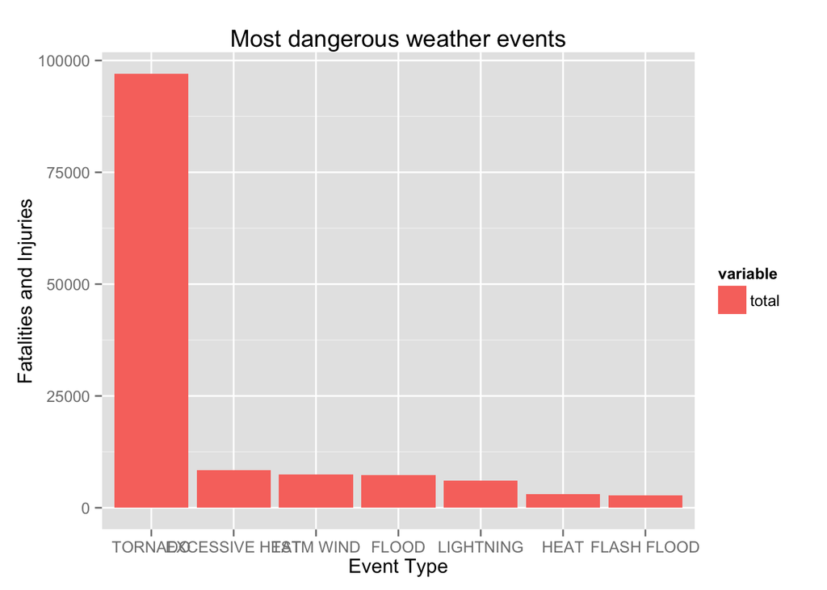

```r
g <- healthData %>%
    group_by(EVTYPE) %>%
    summarise(total = sum(FATALITIES + INJURIES)) %>%
    arrange(desc(total)) %>% # sort by total injuries/fatalities
    head(7) %>% # get top 7
    melt(id.vars = 'EVTYPE') %>% # use reshape2 fn here
    ggplot(aes(x = reorder(EVTYPE, -value), y = value, fill=variable))

g +
    geom_bar(stat="identity") +
    labs(x = "Event Type",
         y = "Fatalities and Injuries",
         title = "Most dangerous weather events")
```

One can see that the most harmful event is tornado.

## economy

Decifer prefixes from *DMGEXP columns using info from https://en.wikipedia.org/wiki/Metric_prefix As we see in `unique(ecoData$cropE)` and `unique(ecoData$propE)` we need to *translate* following symbols: `- ? + 0 1 2 3 4 5 6 7 8 B H K M`. It’s too much to convert from: we have about 900 000 rows in our dataset.

Let’s do a trick.

```r
crop_pos <- ecoData %>%
    filter(cropD>0) %>%
    group_by(event, cropE) %>%
    summarise(total=sum(cropD))
prop_pos <- ecoData %>%
    filter(propD>0) %>%
    group_by(event, propE) %>%
    summarise(total=sum(propD))
```

Those new datasets are much smaller (~200 and ~500 rows) and cleaner. `unique(as.factor(crop_pos$cropE))` and `unique(as.factor(prop_pos$propE))` give as `- + 0 2 3 4 5 6 7 B H K M`

Prepare some calculations

```r
scaledValue <- function(valuesVector, expVector) {
    result  <-  vector(mode = 'numeric')
    for(i in 1:length(expVector)){
        exp <- expVector[i]
        multiplier <- 1
        if (exp %in% c('0','1','2','3','4','5','6','7','8','9')) {
            multiplier <- 10^as.numeric(exp)
        } else if (exp %in% c('H', 'K', 'M', 'B')) {
            multiplier <- switch(exp, H = 100, K = 1000, M = 1000000, B = 1000000000, 0)
        }
        result[i] <- multiplier * valuesVector[i]
    }
    result
}
```

```r
cropDmg <- crop_pos %>%
    mutate(result = scaledValue(total, cropE)) %>%
    group_by(event) %>%
    summarise(totalC=sum(total)) %>%
    arrange(desc(totalC)) # sort by total injuries/fatalities

propDmg <- prop_pos %>%
    mutate(result = scaledValue(total, propE)) %>%
    group_by(event) %>%
    summarise(totalP=sum(total)) %>%
    arrange(desc(totalP)) # sort by total injuries/fatalities
```

Merge and draw data

[figure not shown]

```r
fullDmg <- full_join(cropDmg, propDmg, by = 'event') %>%
    group_by(event) %>%
    summarise(total=sum(totalC + totalP)) %>%
    arrange(desc(total)) # sort by total injuries/fatalities


g <- fullDmg %>%
    head(7) %>% # get top 7
    melt(id.vars = 'event') %>% # use reshape2 fn here
    ggplot(aes(x = reorder(event, -value), y = value / 100000, fill=variable))

g +
    geom_bar(stat="identity") +
    labs(x = "Event Type",
         y = "Crops and Property damages",
         title = "Most dangerous health events")
```